# Communicate Data Finding

Ford GoBike System Data

## Preliminary Wrangling

> Ford GoBike is a regional public bicycle sharing system located in San Francisco Bay Area. This dataset shows history data of individual rides made in a bike-sharing system at 2019.

```python
# import all packages and set plots to be embedded inline
import numpy as np
import pandas as pd
import matplotlib.pyplot as plt
import seaborn as sb

%matplotlib inline
```

## Data Gathering

```python
# Load dataset
bike_rent = pd.read_csv('201902-fordgobike-tripdata.csv')
bike_rent.head()
```

|  | duration_sec | start_time | end_time | start_station_id | start_station_name | start_station_latitude | start_station_longitude | end_station_id | end_station_name | end_station_latitude | end_station_longitude | bike_id | user_type | member_birth_year | member_gender | bike_share_for_all_trip |
| --- | --- | --- | --- | --- | --- | --- | --- | --- | --- | --- | --- | --- | --- | --- | --- | --- |
| 0 | 52185 | 2019-02-28 17:32:10.1450 | 2019-03-01 08:01:55.9750 | 21.0 | Montgomery St BART Station (Market St at 2nd St) | 37.789625 | -122.400811 | 13.0 | Commercial St at Montgomery St | 37.794231 | -122.402923 | 4902 | Customer | 1984.0 | Male | No |
| 1 | 42521 | 2019-02-28 18:53:21.7890 | 2019-03-01 06:42:03.0560 | 23.0 | The Embarcadero at Steuart St | 37.791464 | -122.391034 | 81.0 | Berry St at 4th St | 37.775880 | -122.393170 | 2535 | Customer | NaN | NaN | No |
| 2 | 61854 | 2019-02-28 12:13:13.2180 | 2019-03-01 05:24:08.1460 | 86.0 | Market St at Dolores St | 37.769305 | -122.426826 | 3.0 | Powell St BART Station (Market St at 4th St) | 37.786375 | -122.404904 | 5905 | Customer | 1972.0 | Male | No |
| 3 | 36490 | 2019-02-28 17:54:26.0100 | 2019-03-01 04:02:36.8420 | 375.0 | Grove St at Masonic Ave | 37.774836 | -122.446546 | 70.0 | Central Ave at Fell St | 37.773311 | -122.444293 | 6638 | Subscriber | 1989.0 | Other | No |
| 4 | 1585 | 2019-02-28 23:54:18.5490 | 2019-03-01 00:20:44.0740 | 7.0 | Frank H Ogawa Plaza | 37.804562 | -122.271738 | 222.0 | 10th Ave at E 15th St | 37.792714 | -122.248780 | 4898 | Subscriber | 1974.0 | Male | Yes |

### What is the structure of your dataset?

The original dataset contains 183412 rides and 16 features. I added three additional features by feature engineering.

1. `duration_sec`: the trip duration in seconed
2. `start_time`: the trip start time with date
3. `end_time`: the trip end time with date
4. `start_station_id`: start station id
5. `start_station_name`: start station name
6. `start_station_latitude`: start station latitude
7. `start_station_longitude`: start station longitude
8. `end_station_id`: end station id
9. `end_station_name`: end station name
10. `end_station_latitude`: end station latitude
11. `end_station_longitude`: end station longitude
12. `bike_id`: rented bike id
13. `user_type`: user type either Subscriber or Customer
14. `member_birth_year`: member year of birth
15. `member_gender`: member gender
16. `bike_share_for_all_trip` : True if the member enrolled in the "Bike Share for All" program for low-income residents **Additional features**
17. `member_age`: age of user
18. `hours`: time of ride
19. `weekdays`: day of ride

### What is/are the main feature(s) of interest in your dataset?

- Age
- Gender
- Membership Status
- Weekday
- Hour

### What features in the dataset do you think will help support your investigation into your feature(s) of interest?

1. `user_type`
2. `member_gender`
3. `member_age`
4. `hours`
5. `weekdays`

## Data Assessing

```python
# View the tabel for visual Assessment
bike_rent
```

|  | duration_sec | start_time | end_time | start_station_id | start_station_name | start_station_latitude | start_station_longitude | end_station_id | end_station_name | end_station_latitude | end_station_longitude | bike_id | user_type | member_birth_year | member_gender | bike_share_for_all_trip |
| --- | --- | --- | --- | --- | --- | --- | --- | --- | --- | --- | --- | --- | --- | --- | --- | --- |
| 0 | 52185 | 2019-02-28 17:32:10.1450 | 2019-03-01 08:01:55.9750 | 21.0 | Montgomery St BART Station (Market St at 2nd St) | 37.789625 | -122.400811 | 13.0 | Commercial St at Montgomery St | 37.794231 | -122.402923 | 4902 | Customer | 1984.0 | Male | No |
| 1 | 42521 | 2019-02-28 18:53:21.7890 | 2019-03-01 06:42:03.0560 | 23.0 | The Embarcadero at Steuart St | 37.791464 | -122.391034 | 81.0 | Berry St at 4th St | 37.775880 | -122.393170 | 2535 | Customer | NaN | NaN | No |
| 2 | 61854 | 2019-02-28 12:13:13.2180 | 2019-03-01 05:24:08.1460 | 86.0 | Market St at Dolores St | 37.769305 | -122.426826 | 3.0 | Powell St BART Station (Market St at 4th St) | 37.786375 | -122.404904 | 5905 | Customer | 1972.0 | Male | No |
| 3 | 36490 | 2019-02-28 17:54:26.0100 | 2019-03-01 04:02:36.8420 | 375.0 | Grove St at Masonic Ave | 37.774836 | -122.446546 | 70.0 | Central Ave at Fell St | 37.773311 | -122.444293 | 6638 | Subscriber | 1989.0 | Other | No |
| 4 | 1585 | 2019-02-28 23:54:18.5490 | 2019-03-01 00:20:44.0740 | 7.0 | Frank H Ogawa Plaza | 37.804562 | -122.271738 | 222.0 | 10th Ave at E 15th St | 37.792714 | -122.248780 | 4898 | Subscriber | 1974.0 | Male | Yes |
| ... | ... | ... | ... | ... | ... | ... | ... | ... | ... | ... | ... | ... | ... | ... | ... | ... |
| 183407 | 480 | 2019-02-01 00:04:49.7240 | 2019-02-01 00:12:50.0340 | 27.0 | Beale St at Harrison St | 37.788059 | -122.391865 | 324.0 | Union Square (Powell St at Post St) | 37.788300 | -122.408531 | 4832 | Subscriber | 1996.0 | Male | No |
| 183408 | 313 | 2019-02-01 00:05:34.7440 | 2019-02-01 00:10:48.5020 | 21.0 | Montgomery St BART Station (Market St at 2nd St) | 37.789625 | -122.400811 | 66.0 | 3rd St at Townsend St | 37.778742 | -122.392741 | 4960 | Subscriber | 1984.0 | Male | No |
| 183409 | 141 | 2019-02-01 00:06:05.5490 | 2019-02-01 00:08:27.2200 | 278.0 | The Alameda at Bush St | 37.331932 | -121.904888 | 277.0 | Morrison Ave at Julian St | 37.333658 | -121.908586 | 3824 | Subscriber | 1990.0 | Male | Yes |
| 183410 | 139 | 2019-02-01 00:05:34.3600 | 2019-02-01 00:07:54.2870 | 220.0 | San Pablo Ave at MLK Jr Way | 37.811351 | -122.273422 | 216.0 | San Pablo Ave at 27th St | 37.817827 | -122.275698 | 5095 | Subscriber | 1988.0 | Male | No |
| 183411 | 271 | 2019-02-01 00:00:20.6360 | 2019-02-01 00:04:52.0580 | 24.0 | Spear St at Folsom St | 37.789677 | -122.390428 | 37.0 | 2nd St at Folsom St | 37.785000 | -122.395936 | 1057 | Subscriber | 1989.0 | Male | No |

183412 rows × 16 columns

> **Observations**
> - Nan value in `member_gender` column for bike ID 2535

```python
# Another visual assessment
bike_rent.sample(15)
```

|  | duration_sec | start_time | end_time | start_station_id | start_station_name | start_station_latitude | start_station_longitude | end_station_id | end_station_name | end_station_latitude | end_station_longitude | bike_id | user_type | member_birth_year | member_gender | bike_share_for_all_trip |
| --- | --- | --- | --- | --- | --- | --- | --- | --- | --- | --- | --- | --- | --- | --- | --- | --- |
| 20048 | 793 | 2019-02-26 14:15:19.4390 | 2019-02-26 14:28:32.9370 | 9.0 | Broadway at Battery St | 37.798572 | -122.400869 | 30.0 | San Francisco Caltrain (Townsend St at 4th St) | 37.776598 | -122.395282 | 4934 | Subscriber | 1990.0 | Male | No |
| 78907 | 475 | 2019-02-18 18:24:43.5990 | 2019-02-18 18:32:38.9120 | 285.0 | Webster St at O'Farrell St | 37.783521 | -122.431158 | 58.0 | Market St at 10th St | 37.776619 | -122.417385 | 5949 | Subscriber | 1968.0 | Female | No |
| 118523 | 445 | 2019-02-11 18:48:29.7610 | 2019-02-11 18:55:55.4300 | 67.0 | San Francisco Caltrain Station 2 (Townsend St... | 37.776639 | -122.395526 | 23.0 | The Embarcadero at Steuart St | 37.791464 | -122.391034 | 5566 | Subscriber | 1992.0 | Male | No |
| 7975 | 547 | 2019-02-28 08:39:57.2140 | 2019-02-28 08:49:04.5430 | 197.0 | El Embarcadero at Grand Ave | 37.808848 | -122.249680 | 163.0 | Lake Merritt BART Station | 37.797320 | -122.265320 | 4918 | Subscriber | 1990.0 | Male | No |
| 64335 | 460 | 2019-02-20 12:19:46.3040 | 2019-02-20 12:27:27.2830 | 197.0 | El Embarcadero at Grand Ave | 37.808848 | -122.249680 | 181.0 | Grand Ave at Webster St | 37.811377 | -122.265192 | 198 | Customer | 1970.0 | Female | No |
| 171233 | 328 | 2019-02-03 22:55:53.7360 | 2019-02-03 23:01:22.5190 | 239.0 | Bancroft Way at Telegraph Ave | 37.868813 | -122.258764 | 238.0 | MLK Jr Way at University Ave | 37.871719 | -122.273068 | 5455 | Subscriber | 1994.0 | Male | No |
| 28751 | 638 | 2019-02-25 08:21:17.2120 | 2019-02-25 08:31:55.3540 | 167.0 | College Ave at Harwood Ave | 37.848152 | -122.252160 | 212.0 | Mosswood Park | 37.824893 | -122.260437 | 4900 | Subscriber | 1985.0 | Female | No |
| 52088 | 700 | 2019-02-21 17:27:20.2470 | 2019-02-21 17:39:01.0370 | 81.0 | Berry St at 4th St | 37.775880 | -122.393170 | 24.0 | Spear St at Folsom St | 37.789677 | -122.390428 | 1815 | Subscriber | 1979.0 | Male | No |
| 71907 | 820 | 2019-02-19 17:00:53.9610 | 2019-02-19 17:14:34.5940 | 8.0 | The Embarcadero at Vallejo St | 37.799953 | -122.398525 | 30.0 | San Francisco Caltrain (Townsend St at 4th St) | 37.776598 | -122.395282 | 5831 | Subscriber | 1979.0 | Male | No |
| 109976 | 750 | 2019-02-12 18:19:27.9980 | 2019-02-12 18:31:58.0730 | 15.0 | San Francisco Ferry Building (Harry Bridges Pl... | 37.795392 | -122.394203 | 58.0 | Market St at 10th St | 37.776619 | -122.417385 | 4654 | Subscriber | NaN | NaN | No |
| 37405 | 550 | 2019-02-23 14:11:29.5180 | 2019-02-23 14:20:39.8420 | 212.0 | Mosswood Park | 37.824893 | -122.260437 | 182.0 | 19th Street BART Station | 37.809013 | -122.268247 | 4640 | Subscriber | 1990.0 | Male | No |
| 59669 | 238 | 2019-02-20 19:49:00.6460 | 2019-02-20 19:52:58.6490 | 370.0 | Jones St at Post St | 37.787327 | -122.413278 | 368.0 | Myrtle St at Polk St | 37.785434 | -122.419622 | 6291 | Subscriber | 1981.0 | Male | No |
| 157614 | 896 | 2019-02-05 21:08:57.2460 | 2019-02-05 21:23:53.9970 | 113.0 | Franklin Square | 37.764555 | -122.410345 | 324.0 | Union Square (Powell St at Post St) | 37.788300 | -122.408531 | 4586 | Subscriber | 1980.0 | Male | No |
| 41663 | 410 | 2019-02-22 18:18:25.1780 | 2019-02-22 18:25:15.7190 | 74.0 | Laguna St at Hayes St | 37.776435 | -122.426244 | 42.0 | San Francisco City Hall (Polk St at Grove St) | 37.778650 | -122.418230 | 5552 | Customer | 1984.0 | Female | No |
| 47836 | 234 | 2019-02-22 08:31:29.4730 | 2019-02-22 08:35:24.1850 | 195.0 | Bay Pl at Vernon St | 37.812314 | -122.260779 | 182.0 | 19th Street BART Station | 37.809013 | -122.268247 | 511 | Subscriber | 1989.0 | Male | No |

```python
# Data properties and null values
bike_rent.info()
```

```
<class 'pandas.core.frame.DataFrame'>
RangeIndex: 183412 entries, 0 to 183411
Data columns (total 16 columns):
 #   Column                   Non-Null Count   Dtype
---  ------                   --------------   -----
 0   duration_sec             183412 non-null  int64
 1   start_time               183412 non-null  object
 2   end_time                 183412 non-null  object
 3   start_station_id         183215 non-null  float64
 4   start_station_name       183215 non-null  object
 5   start_station_latitude   183412 non-null  float64
 6   start_station_longitude  183412 non-null  float64
 7   end_station_id           183215 non-null  float64
 8   end_station_name         183215 non-null  object
 9   end_station_latitude     183412 non-null  float64
 10  end_station_longitude    183412 non-null  float64
 11  bike_id                  183412 non-null  int64
 12  user_type                183412 non-null  object
 13  member_birth_year        175147 non-null  float64
 14  member_gender            175147 non-null  object
 15  bike_share_for_all_trip  183412 non-null  object
dtypes: float64(7), int64(2), object(7)
memory usage: 22.4+ MB
```

> **Observations**
> - Null values at `member_birth_year` and `member_gender` columns
> - `start_time` column in string format rather than datetime
> - Values in `member_birth_year` column are float rather than integer
> - `user_type` and `member_gender` columns in string format rather than category

```python
# view summary statistics on numeric columns
bike_rent.describe()
```

|  | duration_sec | start_station_id | start_station_latitude | start_station_longitude | end_station_id | end_station_latitude | end_station_longitude | bike_id | member_birth_year |
| --- | --- | --- | --- | --- | --- | --- | --- | --- | --- |
| count | 183412.000000 | 183215.000000 | 183412.000000 | 183412.000000 | 183215.000000 | 183412.000000 | 183412.000000 | 183412.000000 | 175147.000000 |
| mean | 726.078435 | 138.590427 | 37.771223 | -122.352664 | 136.249123 | 37.771427 | -122.352250 | 4472.906375 | 1984.806437 |
| std | 1794.389780 | 111.778864 | 0.099581 | 0.117097 | 111.515131 | 0.099490 | 0.116673 | 1664.383394 | 10.116689 |
| min | 61.000000 | 3.000000 | 37.317298 | -122.453704 | 3.000000 | 37.317298 | -122.453704 | 11.000000 | 1878.000000 |
| 25% | 325.000000 | 47.000000 | 37.770083 | -122.412408 | 44.000000 | 37.770407 | -122.411726 | 3777.000000 | 1980.000000 |
| 50% | 514.000000 | 104.000000 | 37.780760 | -122.398285 | 100.000000 | 37.781010 | -122.398279 | 4958.000000 | 1987.000000 |
| 75% | 796.000000 | 239.000000 | 37.797280 | -122.286533 | 235.000000 | 37.797320 | -122.288045 | 5502.000000 | 1992.000000 |
| max | 85444.000000 | 398.000000 | 37.880222 | -121.874119 | 398.000000 | 37.880222 | -121.874119 | 6645.000000 | 2001.000000 |

### Issues summary

1. Wrong datatype for `start_time`,`user_type`,`member_gender` and `member_birth_year` columns
2. Missing values in`member_gender` and `member_birth_year` columns
3. Age info extraction from `member_birth_year` column
4. Age outliers removing
5. Hours and weekdays info extraction from `start_time` column
6. The five features of interest are related (forms a table)

## Data Cleaning

```python
# Make copy of original pieces of data
bike_rent_clean = bike_rent.copy()
```

### Issue 1: Missing values in`member_gender` and `member_birth_year` columns

#### Define

Drop the missing values in the two columns.

#### Code

```python
bike_rent_clean = bike_rent_clean[bike_rent_clean.member_birth_year.notnull()]
bike_rent_clean = bike_rent_clean[bike_rent_clean.member_gender.notnull()]
```

#### Test

```python
print('Null values in member birth year column is ',
      bike_rent_clean.member_birth_year.isna().sum())
print('Null values in member gender column is ',
      bike_rent_clean.member_gender.isna().sum())
```

```
Null values in member birth year column is  0
Null values in member gender column is  0
```

### Issue 2: Wrong datatype for `start_time`,`user_type`,`member_gender` and `member_birth_year` columns

#### Define

Change `user_type` and `member_gender` columns to category using astype method. Change column `member_birth_year` to int. Change column `start_time` to datetime format.

#### Code

```python
bike_rent_clean.user_type = bike_rent_clean.user_type.astype('category')
bike_rent_clean.member_gender = bike_rent_clean.member_gender.astype('category')
bike_rent_clean.member_birth_year = bike_rent_clean.member_birth_year.astype(int)
bike_rent_clean.start_time = pd.to_datetime(bike_rent_clean.start_time)
```

#### Test

```python
bike_rent_clean.info()
```

```
<class 'pandas.core.frame.DataFrame'>
Int64Index: 175147 entries, 0 to 183411
Data columns (total 16 columns):
 #   Column                   Non-Null Count   Dtype
---  ------                   --------------   -----
 0   duration_sec             175147 non-null  int64
 1   start_time               175147 non-null  datetime64[ns]
 2   end_time                 175147 non-null  object
 3   start_station_id         174952 non-null  float64
 4   start_station_name       174952 non-null  object
 5   start_station_latitude   175147 non-null  float64
 6   start_station_longitude  175147 non-null  float64
 7   end_station_id           174952 non-null  float64
 8   end_station_name         174952 non-null  object
 9   end_station_latitude     175147 non-null  float64
 10  end_station_longitude    175147 non-null  float64
 11  bike_id                  175147 non-null  int64
 12  user_type                175147 non-null  category
 13  member_birth_year        175147 non-null  int32
 14  member_gender            175147 non-null  category
 15  bike_share_for_all_trip  175147 non-null  object
dtypes: category(2), datetime64[ns](1), float64(6), int32(1), int64(2), object(4)
memory usage: 19.7+ MB
```

### Issue 3: Age info extraction from `member_birth_year` column

#### Define

Create `age` column by subtracting birth year from 2019.

#### Code

```python
bike_rent_clean['member_age'] = 2019 - bike_rent_clean['member_birth_year']
```

#### Test

```python
bike_rent_clean.sample()
```

|  | duration_sec | start_time | end_time | start_station_id | start_station_name | start_station_latitude | start_station_longitude | end_station_id | end_station_name | end_station_latitude | end_station_longitude | bike_id | user_type | member_birth_year | member_gender | bike_share_for_all_trip | member_age |
| --- | --- | --- | --- | --- | --- | --- | --- | --- | --- | --- | --- | --- | --- | --- | --- | --- | --- |
| 178055 | 897 | 2019-02-01 17:51:24.650 | 2019-02-01 18:06:22.4180 | 256.0 | Hearst Ave at Euclid Ave | 37.875112 | -122.260553 | 254.0 | Vine St at Shattuck Ave | 37.880222 | -122.269592 | 4890 | Subscriber | 1993 | Female | Yes | 26 |

```python
bike_rent_clean.member_age.dtype
```

```
dtype('int32')
```

### Issue 4: Age outliers removing

Discovering outliers by using box plot and pandas statical summary

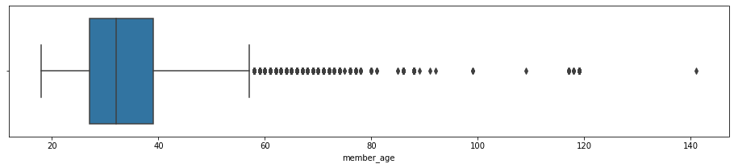

```python
# Change size of plot
plt.figure(figsize = [16, 3])

# Choose plot color
plot_color = sb.color_palette()[0]

# Create box plot
sb.boxplot(data= bike_rent_clean, x='member_age', color= plot_color);
```

```python
# Show statical summery
bike_rent_clean.member_age.describe(percentiles = [0.95])
```

```
count    175147.000000
mean         34.193563
std          10.116689
min          18.000000
50%          32.000000
95%          55.000000
max         141.000000
Name: member_age, dtype: float64
```

The box plot and 95% percentile using describe pandas function show older users above 55 years old to be outliers. So, I chose to drop rows above 60 years old.

#### Define

Drop rows with member age higher than 60 years old.

#### Code

```python
bike_rent_clean = bike_rent_clean.query('member_age <= 60')
```

#### Test

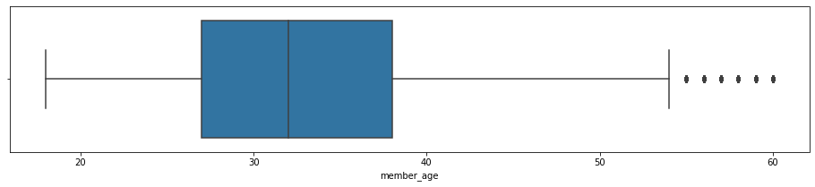

```python
plt.figure(figsize = [16, 3])
plot_color = sb.color_palette()[0]
sb.boxplot(data= bike_rent_clean, x='member_age', color= plot_color);
```

### Issue 5: Hours and weekdays info extraction from `start_time` column

#### Define

Create `hours` and `weekdays` columns from `start_time` column and change `weekdays` to category format.

#### Code

```python
bike_rent_clean['hours'] = bike_rent_clean['start_time'].dt.hour
bike_rent_clean['weekdays'] = bike_rent_clean['start_time'].dt.day_name().astype('category')
```

#### Test

```python
bike_rent_clean.info()
```

```
<class 'pandas.core.frame.DataFrame'>
Int64Index: 171617 entries, 0 to 183411
Data columns (total 19 columns):
 #   Column                   Non-Null Count   Dtype
---  ------                   --------------   -----
 0   duration_sec             171617 non-null  int64
 1   start_time               171617 non-null  datetime64[ns]
 2   end_time                 171617 non-null  object
 3   start_station_id         171422 non-null  float64
 4   start_station_name       171422 non-null  object
 5   start_station_latitude   171617 non-null  float64
 6   start_station_longitude  171617 non-null  float64
 7   end_station_id           171422 non-null  float64
 8   end_station_name         171422 non-null  object
 9   end_station_latitude     171617 non-null  float64
 10  end_station_longitude    171617 non-null  float64
 11  bike_id                  171617 non-null  int64
 12  user_type                171617 non-null  category
 13  member_birth_year        171617 non-null  int32
 14  member_gender            171617 non-null  category
 15  bike_share_for_all_trip  171617 non-null  object
 16  member_age               171617 non-null  int32
 17  hours                    171617 non-null  int64
 18  weekdays                 171617 non-null  category
dtypes: category(3), datetime64[ns](1), float64(6), int32(2), int64(3), object(4)
memory usage: 21.4+ MB
```

```python
bike_rent_clean.sample(5)
```

|  | duration_sec | start_time | end_time | start_station_id | start_station_name | start_station_latitude | start_station_longitude | end_station_id | end_station_name | end_station_latitude | end_station_longitude | bike_id | user_type | member_birth_year | member_gender | bike_share_for_all_trip | member_age | hours | weekdays |
| --- | --- | --- | --- | --- | --- | --- | --- | --- | --- | --- | --- | --- | --- | --- | --- | --- | --- | --- | --- |
| 56330 | 670 | 2019-02-21 09:03:48.127 | 2019-02-21 09:14:58.4340 | 66.0 | 3rd St at Townsend St | 37.778742 | -122.392741 | 22.0 | Howard St at Beale St | 37.789756 | -122.394643 | 1821 | Subscriber | 1988 | Male | No | 31 | 9 | Thursday |
| 5143 | 871 | 2019-02-28 13:48:44.816 | 2019-02-28 14:03:16.1590 | 341.0 | Fountain Alley at S 2nd St | 37.336188 | -121.889277 | 341.0 | Fountain Alley at S 2nd St | 37.336188 | -121.889277 | 6128 | Subscriber | 1995 | Male | Yes | 24 | 13 | Thursday |
| 116081 | 931 | 2019-02-12 08:01:57.167 | 2019-02-12 08:17:28.8480 | 119.0 | 18th St at Noe St | 37.761047 | -122.432642 | 66.0 | 3rd St at Townsend St | 37.778742 | -122.392741 | 5218 | Subscriber | 1992 | Female | No | 27 | 8 | Tuesday |
| 138900 | 399 | 2019-02-08 01:01:43.305 | 2019-02-08 01:08:23.2240 | 252.0 | Channing Way at Shattuck Ave | 37.865847 | -122.267443 | 263.0 | Channing Way at San Pablo Ave | 37.862827 | -122.290231 | 3547 | Subscriber | 1992 | Male | No | 27 | 1 | Friday |
| 105599 | 174 | 2019-02-13 22:20:03.892 | 2019-02-13 22:22:58.3080 | 245.0 | Downtown Berkeley BART | 37.870139 | -122.268422 | 252.0 | Channing Way at Shattuck Ave | 37.865847 | -122.267443 | 328 | Subscriber | 1990 | Male | No | 29 | 22 | Wednesday |

### Issue 6: The five features of interest are related (forms a table)

#### Define

Create new dataframe contain copy of feature of interest only (5 features).

#### Code

```python
new_df = bike_rent_clean[['user_type','member_gender','member_age','hours','weekdays']].copy()
```

#### Test

```python
new_df.sample(3)
```

|  | user_type | member_gender | member_age | hours | weekdays |
| --- | --- | --- | --- | --- | --- |
| 183262 | Subscriber | Male | 32 | 6 | Friday |
| 90523 | Subscriber | Male | 26 | 12 | Saturday |
| 89530 | Subscriber | Male | 35 | 15 | Saturday |

```python
new_df.info()
```

```
<class 'pandas.core.frame.DataFrame'>
Int64Index: 171617 entries, 0 to 183411
Data columns (total 5 columns):
 #   Column         Non-Null Count   Dtype
---  ------         --------------   -----
 0   user_type      171617 non-null  category
 1   member_gender  171617 non-null  category
 2   member_age     171617 non-null  int32
 3   hours          171617 non-null  int64
 4   weekdays       171617 non-null  category
dtypes: category(3), int32(1), int64(1)
memory usage: 3.8 MB
```

## Store Data

```python
new_df.to_csv('Ford_GoBike_cleaned.csv', index = False)
```

## Data Exploring

```python
# Load the cleaned data
df = pd.read_csv('Ford_GoBike_cleaned.csv')
```

### Q1. What is the distribution of Ford GoBike users age?

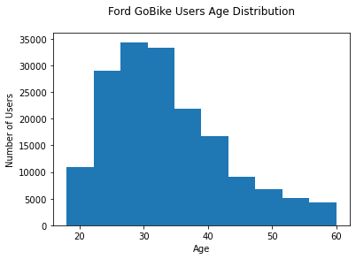

```python
# Create histogram
plt.hist(data = df, x = 'member_age');

# Set plot labels and title
plt.title('Ford GoBike Users Age Distribution\n')
plt.xlabel('Age')
plt.ylabel('Number of Users');
```

The distribution is right-skewed, with the Majority of users from 28 to 33 years old use the GoBike system.

### Q2. What is the proportion of each user gender?

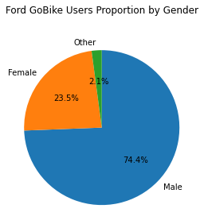

```python
# Get the dynamic ordering of genders
sorted_counts = df['member_gender'].value_counts()

# Create pie plot
plt.pie(sorted_counts, labels = sorted_counts.index, startangle = 90,autopct= '%1.1f%%', counterclock = False);
plt.axis('square');
plt.title('Ford GoBike Users Proportion by Gender\n\n');
```

The male users are more than half with 74.4%, while 23.5% goes for female users and 2.1% for other gender.

### Q3. What is the proportion of each user type?

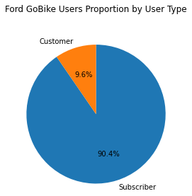

```python
# Get the dynamic ordering of user types
sorted_counts = df['user_type'].value_counts()

# Plot pie chart
plt.pie(sorted_counts, labels = sorted_counts.index,startangle = 90,autopct= '%1.1f%%', counterclock = False);
plt.axis('square');
plt.title('Ford GoBike Users Proportion by User Type\n\n');
```

Most users are subscriber with 90.4% compared to customer users with 9.6%.

### Q4. What is the distribution of the Ford GoBik hourly usage?

```python
# Create x-axis ticks with step-size 2
tick = np.arange(0,df.hours.max()+2,2)

# Create bins with step-size 1
bins = np.arange(0,df.hours.max()+1,1)
```

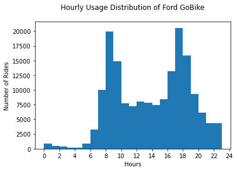

```python
# Plot histogram
plt.hist(data = df, x= 'hours', bins = bins);

# Set plot labels and title
plt.title('Hourly Usage Distribution of Ford GoBike\n')
plt.xlabel('Hours')
plt.ylabel('Number of Rides')

# Change the x-axis ticks in histogram
plt.xticks(tick);
```

The graph shows two traffic peaks during the day, around 8–9 AM and 5–6 PM. I think that indicates a lot of people go and leave their work using bikes.

### Q5. What is the weekly usage of Ford GoBik system?

```python
weekday = ['Monday', 'Tuesday', 'Wednesday', 'Thursday', 'Friday', 'Saturday', 'Sunday']

# Returns the days for weekday with the categories and orderedness
weekday_classes = pd.api.types.CategoricalDtype(ordered=True, categories=weekday)

# Convert the "weekday_classes" column from a plain object type into an ordered categorical type
df['weekdays'] = df['weekdays'].astype(weekday_classes);
```

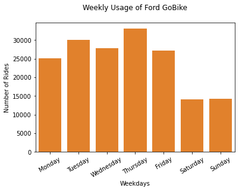

```python
# Plot bars color
plot_color = sb.color_palette()[1]

# Create barchart
sb.countplot(data = df, x= 'weekdays', order = weekday, color = plot_color);

# Set plot labels and title
plt.title('Weekly Usage of Ford GoBike\n')
plt.xlabel('Weekdays')
plt.ylabel('Number of Rides')
plt.xticks(rotation = 30);
```

This graph shows that people ride the bike on weekdays more than on weekends.

### Discuss the distribution(s) of your variable(s) of interest. Were there any unusual points? Did you need to perform any transformations?

Summary of discovered pattern in the dataset:

- Most GoBike users age between 28-33 years old.
- Majority of users gender are male.
- Majority of user type is a subscriber.
- Number of bike rides on weekdays are higher than on weekends.
- Number of bike rides at peaks between 8–9 AM and 5–6 PM.

### Of the features you investigated, were there any unusual distributions? Did you perform any operations on the data to tidy, adjust, or change the form of the data? If so, why did you do this?

In Ford GoBike, User’s Age Distribution had outliers. With more investigation, I chose to drop ages higher than 60 as 95% of the dataset with age 55.

## Bivariate Exploration

### Q1. What is the relation between users age and their gender?

```python
gender = ['Male', 'Female', 'Other']

# Returns the types for member_gender with the categories and orderedness
gender_classes = pd.api.types.CategoricalDtype(ordered=True, categories=gender)

# Convert the "gender_classes" column from a plain object type into an ordered categorical type
df['member_gender'] = df['member_gender'].astype(gender_classes);
```

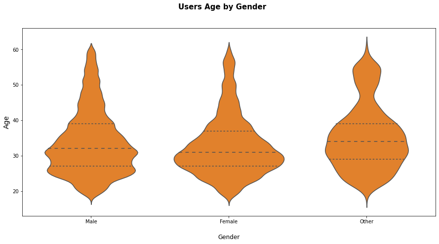

```python
# Set figure size
fig = plt.figure(figsize = [15,7])

# Plot violin plot
# categorical vs numerical
sb.violinplot(data=df, x='member_gender', y='member_age', color=plot_color, inner = 'quartile')

# Set title and axis labels
plt.xlabel('Gender', fontsize=12,labelpad = 20)
plt.ylabel('Age', fontsize=14)
fig.suptitle('Users Age by Gender', fontsize=15, fontweight = 'bold');
```

The male and female median ages are close to each other, whereas the other gender is slightly higher. We can see that females in nearly 30s tend to ride bikes than all different genders. Another thing to notice is the other gender has more users at age 50s.

### Q2. Does the number of users gender differ between users type?

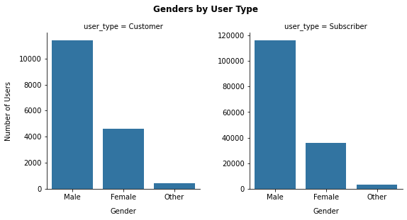

```python
# Plot the seaborn's FacetGrid
# categorical vs categorical
plot_1 = sb.FacetGrid(data = df, col = 'user_type', sharey = False, height = 4)
plot_1.map(sb.countplot, 'member_gender', order = gender)

# Set plot labels and title
plot_1.set_axis_labels('Gender','Number of Users', labelpad = 10)
plot_1.fig.suptitle('Genders by User Type', y= 1.05, fontweight='bold');
```

The result above shows that the range of the y-axis of subscriber user type is higher than the customer as we noted before. Also, for each user type, most users were male.

### Q3. Does users age distribution differ between users type?

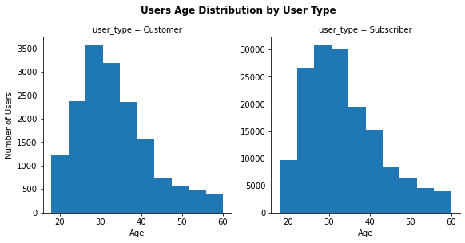

```python
# Plot FacetGrid
# categorical Vs numerical
plot_2 = sb.FacetGrid(data = df, col = 'user_type', sharey=False, height= 4)
plot_2.map(plt.hist, 'member_age')

# Set title and axis labels
plot_2.set_axis_labels('Age', 'Number of Users')
plot_2.fig.suptitle('Users Age Distribution by User Type', y=1.05, fontweight='bold');
```

The distributions show the Majority of users fall between 28 to 33 years old for both user types.

### Q4. What is the weekly usage for each user type?

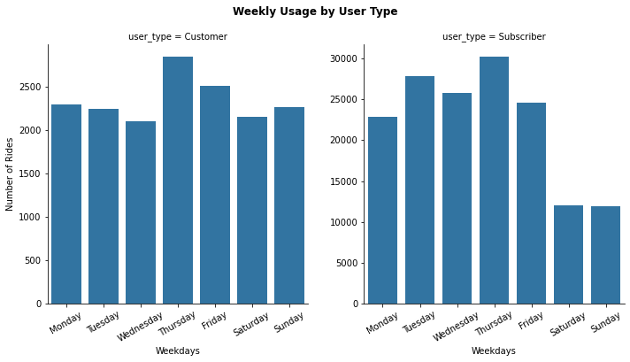

```python
# Plot FacetGrid
# categorical vs numerical
plot_3 = sb.FacetGrid(data = df, col = 'user_type', sharey = False, height =5)
plot_3.map(sb.countplot, 'weekdays', order = weekday)

# Set title and axis labels
plot_3.fig.suptitle('Weekly Usage by User Type', y= 1.05, fontweight='bold')
plot_3.set_axis_labels('Weekdays', 'Number of Rides')
plot_3.set_xticklabels(rotation=30);
```

The two distributions show weekdays have high number of rides than weekends. But, compared with subscribers, customers are more likely to ride bikes on weekends.

### Q5. Would hourly usage be the same for the different users type?

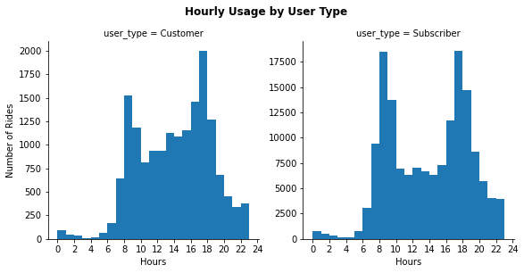

```python
# Create x-axis ticks with step-size 2
tick = np.arange(0,df.hours.max()+2,2)
# Create bins with step-size 1
bins = np.arange(0,df.hours.max()+1,1)

# Plot FacetGrid
# categorical vs numerical
plot_4 = sb.FacetGrid(data = df, col = 'user_type', sharey=False, height = 4)
plot_4.map(plt.hist, 'hours', bins = bins);

# Change x-axis ticks
plt.xticks(tick)

# Set title and axis labels
plot_4.set_axis_labels('Hours', 'Number of Rides')
plot_4.fig.suptitle('Hourly Usage by User Type', y=1.05, fontweight='bold');
```

It seems like customers ride bikes often between 5-6 PM, while subscribers ride bikes during rush hours (8-9 AM and 5-6 PM).

### Talk about some of the relationships you observed in this part of the investigation. How did the feature(s) of interest vary with other features in the dataset?

**`member_gender` vs `member_age`**

- Females in nearly 30s tend to ride bikes than all different genders.
- The other gender has more users at age 50s.

**`member_gender` vs `user_type`**

- Most users were Male for each user type.

**`member_age` vs `user_type`**

- The Majority of users fall between 28 to 33 years old for both user types.

**`weekdays` vs `user_type`**

- Weekdays have high number of rides for both user types.

**`hours` vs `user_type`**

- Customers user type ride bikes often between 5-6 PM, while subscribers ride bikes during rush hours (8-9 AM and 5-6 PM).

## Multivariate Exploration

### Q1. What is the weekly bike usage by users type and genders?

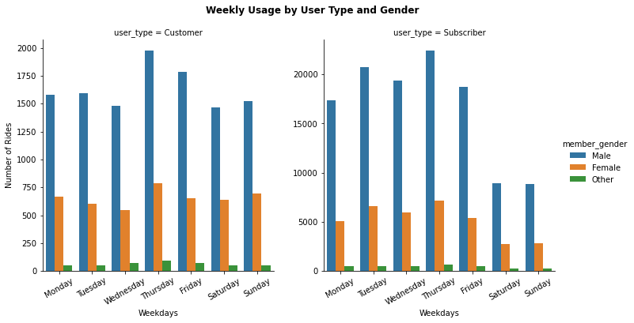

```python
# Plot catplot
# Chose this plot for its flexibility
# dealing with multi categorical data
plot_5 = sb.catplot(data=df, x='weekdays', col='user_type', hue='member_gender',
                kind='count', sharey=False, legend=True)

# Set title and axis labels
plot_5.fig.suptitle('Weekly Usage by User Type and Gender', y= 1.05, fontweight='bold')
plot_5.set_axis_labels('Weekdays', 'Number of Rides')
plot_5.set_xticklabels(rotation=30);
```

The plot supports the previous bivariate plots. For both user types, Most users were Male. The weekdays have high number of rides for both user types.

### Q2. What is the Hourly usage by users type and genders?

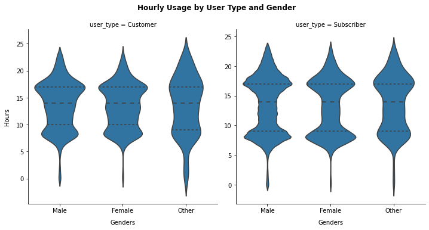

```python
# Plot FacetGrid
plot_6 = sb.FacetGrid(data = df, col = 'user_type', sharey = False, height =5)
plot_6.map(sb.violinplot,'member_gender','hours', order= gender,
          inner = 'quartile')

# Set title and axis labels
plot_6.set_axis_labels('Genders', 'Hours', labelpad = 10)
plot_6.fig.suptitle('Hourly Usage by User Type and Gender', y=1.05, fontweight='bold');
```

Also, This plot supports the previous bivariate plots. Customers users ride bikes often between 5-6 PM, while subscribers ride bikes during rush hours (8-9 AM and 5-6 PM).

### Q3. How is the bike usage distributed on hours and weekdays for customers and subscribers?

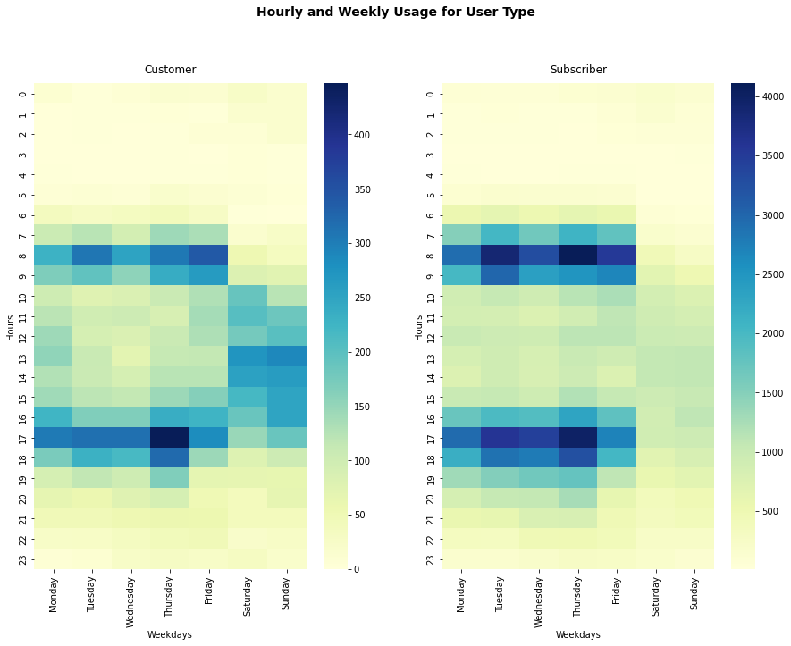

```python
fig = plt.figure(figsize = [15,10])

# Add title for figure
fig.suptitle('Hourly and Weekly Usage for User Type', y=1.00, fontsize = 14, fontweight='bold');

# plot heatmap for customer users
plt.subplot(1, 2, 1)
# Get the number of customer users for each hour and weekday as a pandas series
c_type = df.query('user_type == "Customer"').groupby(["hours", "weekdays"]).size()
# Convert a series into a dataframe object
c_type = c_type.reset_index(name='count')
# Rearrange the data, to have hours on rows
c_type = c_type.pivot(index = 'hours', columns = 'weekdays', values = 'count')
# Plot heatmap with color templete
sb.heatmap(c_type, cmap='YlGnBu')

# Set plot title and axis labels
plt.title('Customer', y=1.01)
plt.xlabel('Weekdays')
plt.ylabel('Hours');


# plot heatmap for subscriber users
plt.subplot(1, 2, 2)
# Get the number of subscriber users for each hour and weekday as a pandas series
s_type = df.query('user_type == "Subscriber"').groupby(["hours", "weekdays"]).size()
# Convert a series into a dataframe object
s_type = s_type.reset_index(name='count')
# Rearrange the data, to have hours on rows
s_type = s_type.pivot(index = 'hours', columns = 'weekdays', values = 'count')
# Plot heatmap with color templete
sb.heatmap(s_type,  cmap= 'YlGnBu')

# Set plot title and axis labels
plt.title('Subscriber', y=1.01)
plt.xlabel('Weekdays')
plt.ylabel('Hours');
```

The plot also shows patterns as the two previous plots.

### Talk about some of the relationships you observed in this part of the investigation. Were there features that strengthened each other in terms of looking at your feature(s) of interest?

The multivariate exploring section did support and prove the founding in the bivariate section. I also notice customers are more likely to ride bikes on weekends, which consider a chance for the company to increase its customer users. I found this point is interesting as I think customer users ride the bike other than for work, unlike subscribe users.

### Were there any interesting or surprising interactions between features?

No, there is no exciting interactions.